# Final Project

Olivia Frary

## Project Aim

The purpose of this project was to consider the predictors of longevity in organisms across the tree of life. I was particularly interested in whether there is a correlation between the degree of difference in size of heterogametic sex chromosomes and lifespan.

## Background information

##### Heteromorphic Sex Chromosomes

##### Why is there a reduced sex chromosome?

## Project Methods

### Step 1: Find and load R packages relevant to dealing with genomic data

```r
# CRAN Packages
library(phangorn)
library(tidyverse)
library(janitor)
library(ape)
library(dplyr)
library(kableExtra)
library(seqinr)
library(reutils)
library(shiny)
library(modelr)
library(MASS)
library(easystats)

# Bioconductor Packages
library(Biostrings)
library(DECIPHER)
library(ggtree)
library(msa)

# Github Packages
library(ggmsa)

#### CONFIRM THE PACKAGES YOU ACTUALLY USED GIRL ####
```

### Step 2: Take a look at the data we have

| class | order | family | species | sex_determination | heterogametic_lifespan | homogametic_lifespan | ln_r_rlifespan | population_source | lifespan_data_type | gs_female_mb | gs_male_mb | gs_diff_mb |
| --- | --- | --- | --- | --- | --- | --- | --- | --- | --- | --- | --- | --- |
| Actinopterygii | Salmoniformes | Salmonidae | Coregonus hoyi | male heterogametic | 9.00 | 11.00 | 0.2006707 | wild | max | NA | NA | NA |
| Actinopterygii | Salmoniformes | Salmonidae | Coregonus kiyi | male heterogametic | 8.00 | 10.00 | 0.2231436 | wild | max | NA | NA | NA |
| Amphibia | Anura | Alytidae | Discoglossus pictus | female heterogametic | 3.08 | 3.00 | -0.0263173 | wild | mean | NA | NA | NA |
| Amphibia | Anura | Dicroglossidae | Fejervarya limnocharis | male heterogametic | 2.00 | 2.20 | 0.0953102 | wild | mean | NA | NA | NA |
| Amphibia | Anura | Pyxicephalidae | Pyxicephalus adspersus | female heterogametic | 4.00 | 6.00 | 0.4054651 | wild | mean | NA | NA | NA |
| Amphibia | Anura | Ranidae | Rana sakuraii | male heterogametic | 3.25 | 3.45 | 0.0597192 | wild | mean | NA | NA | NA |

Here, we are seeing a lot of NA’s. We will sift through this data, first focusing on lifespan differences. Then we will do a tighter filter, including genome size differences which will leave us with 25 observations of the 13 variables.

### Step 3: Make some initial plots of the data we have

#### *Initial Plots: Lifespan*

Lets look at all the species we’ve gathered that have lifespan data for the sexes.

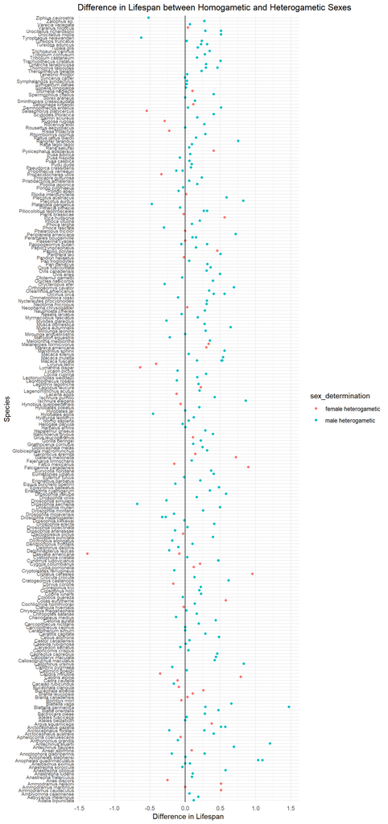

The figure above shows the difference between the lifespan of homogametic and heterogametic sexes of certain species. The x-axis plots ln(homogametic lifespan/heterogametic lifespan) to normalize the results. If the point is above zero, the homogametic sex lives longer. If it is below zero, the heterogametic sex lives longer. The colors are based on whether the species’ sex determination system is female or male heterogametic

The following plot is another way of illustrating how much of the difference in lifespan data resides *above* zero.

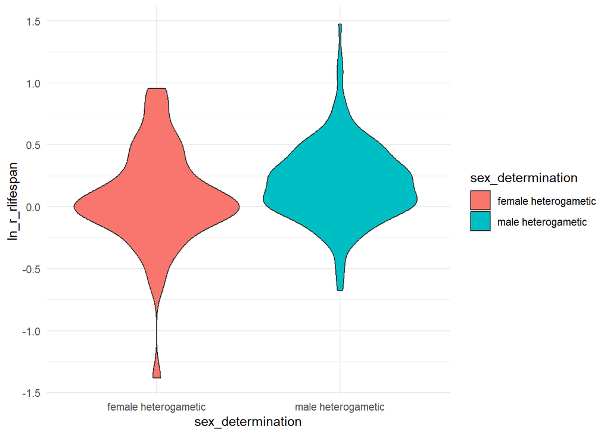

From our lifespan plots, we can see that the homogametic sex lives longer. However, this is not new information. We want to see if the difference in the size of the sex chromosomes contributes to the degree of difference in longevity. To do that we have to narrow our data again to the observations where genome size data was found.

#### *Initial Plots: Genome Size*

Let’s now look at all the species who have both lifespan and genome size data.

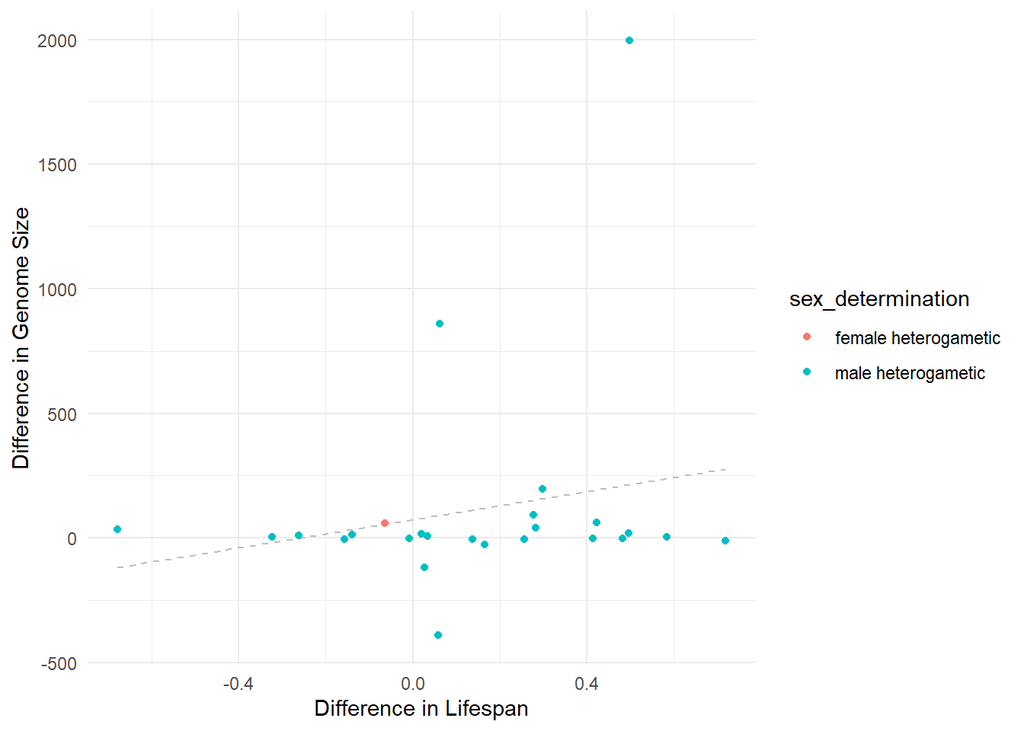

This plot reveals that most of the data we have is male heterogametic. There is only one female heterogametic data point. Also, the outliers make it appear as though there is a trend, but really it is hard to believe that there is actually a positive trend worth noting. From this plot, we can not conclude a correlation between the difference in size of the heterogametic sex chromosomes and the difference in lifespan between the sexes.

Lets quickly restrict the data to a subset of -250:250 Mb to see how the trendline behaves.

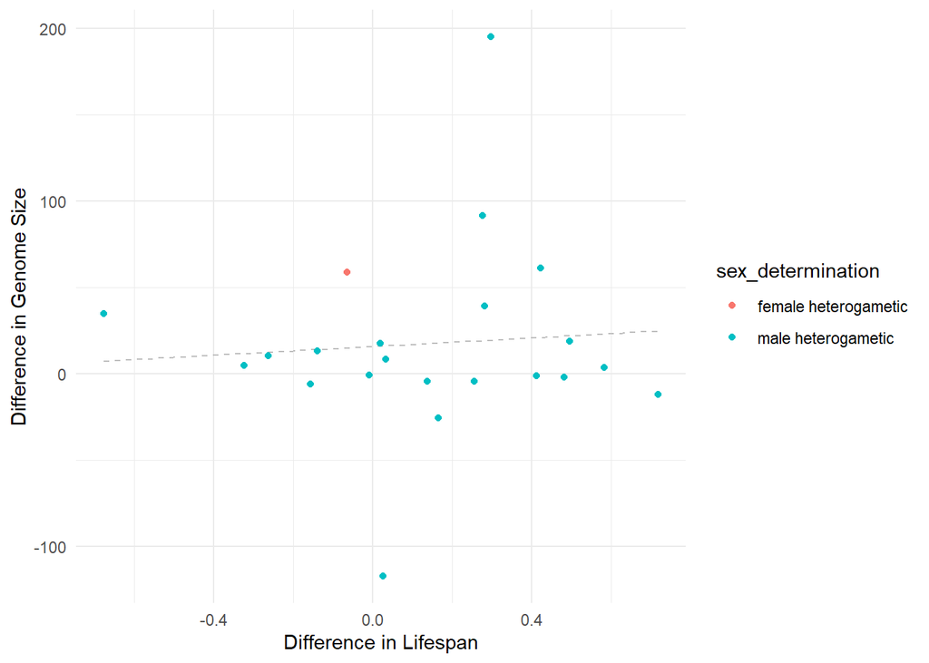

I want to collect more data on the longevity and differences in genome size of species so that I can further investigate a pattern. Until then, let’s make some models based off the data we have and see if the predictions they make will give us a clue into a possible pattern.

### Step 4: Attempt some models

##### Models with larger subset of lifespan data

Model 1 formula to investigate sex determination as a predictor

```
## ln_r_rlifespan ~ sex_determination
```

Model 2 formula to make a complicated model of three predictors

```
## ln_r_rlifespan ~ sex_determination * population_source * lifespan_data_type
```

Model 3 formula, used stepAIC method to find “best” model

```
## ln_r_rlifespan ~ sex_determination + population_source
```

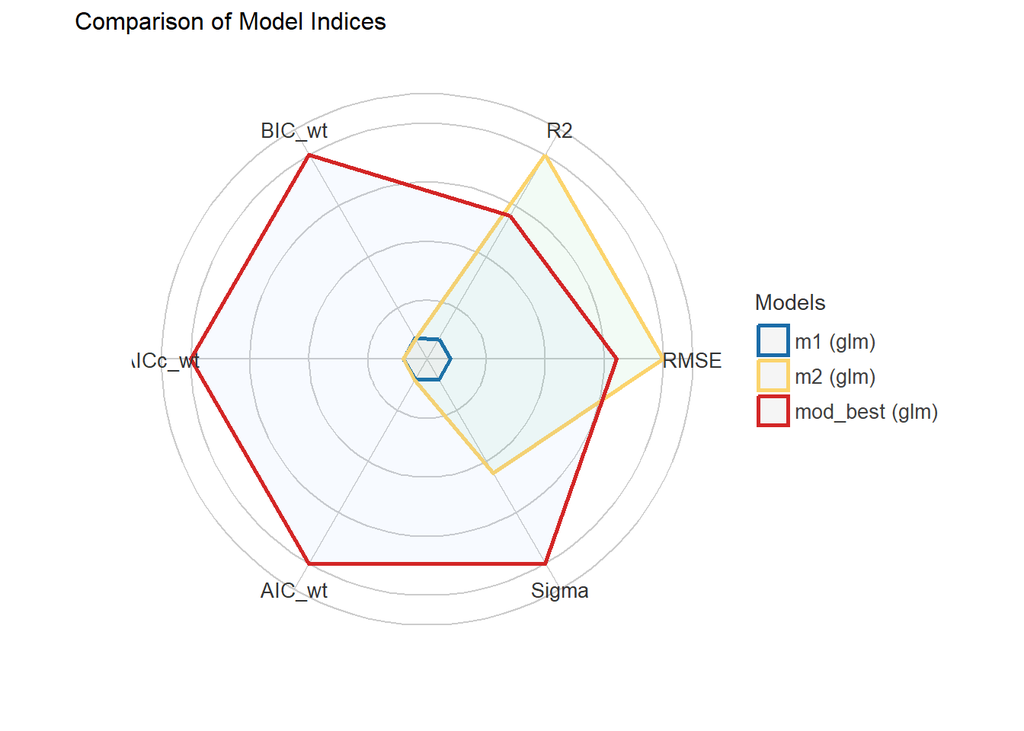

### Step 6: Build pipeline for a phylogeny

Though I still have the goal of collecting more data, I wanted to build a method for creating a phylogenetic tree so that I could implement it in further analyes.

#### *Get accession numbers*

Dr. Carl Hjelman at Utah Valley University worked with me on this piece of code. It’s purpose is to take a list of species and genes from the user and create a data frame of their accession numbers from GenBank. The lengths of the genes found are included in the table to help identify suspicious results.

```r
#### Retrieving Accession Numbers from Genbank ####
#### function that takes a term and finds genbank data for it ####
grab.results <- function (term) {
  # Search for the given term on nuccore. This gives us a list of
  # record IDs.
  ids <- esearch(term, db="nuccore")
  # Grab summaries for the given record IDs, as a sort-of data frame.
  sum <- esummary(ids, db="nuccore")
  data <- content(sum, as="parsed")
  # For some reason, this parser gives us lists of lists instead of a
  # proper data frame (which should be lists of vectors). Return a
  # fixed-up version.
  data.frame(lapply(data, as.character), stringsAsFactors=FALSE)
}

# read in my data and only use the data that I have both lifespan and genome size data for
spec<-read.csv("lifespan_species.csv")
# put in list of genes to collect accessions for
gene.list<-c("mitochondrion","coi","coii", "coiii", "cytb", "hunchback")
# make matrix to be populated
accession_out<-matrix(,nrow=length(spec$names),ncol=(length(gene.list)*2+1))
# make list of column names for table
columns <- list()
columns <- append(columns, "Spec")
for(i in 1:length(gene.list)){
  columns <- append(columns, paste(gene.list[i],"Acc"))
  columns <- append(columns, "Len")
}
colnames(accession_out) <- columns

#loop to add data to table
for(i in 1:length(spec$names)){
  accession_out[i,1] <- spec$names[i]
  for(k in 1:6){
    testing<-(grab.results(term=(paste(spec$names[i],gene.list[k]))))
    if(length(testing)<1){
      (k<-(k+1))}
    #the below lets us know if after we filter to only DNA and remove other species that we still have data
    #this lets us filter out RNA and also organisms that don't match but might appear
    #like parasites, worms, etc.
    else if(length((subset(testing, testing$MolType == "dna" & testing$Organism == spec$names[i] & as.numeric(testing$Slen)<21000))[1])
            <1){
      k<-(k+1)
    }
    #this pulls data if we have data, DNA, and the right species, and filters out things larger than mitochondria
    else{
      testagain<-(subset(testing, testing$MolType == "dna" & testing$Organism == spec$names[i] & as.numeric(testing$Slen)<21000))
      accession_out[i,(k*2)]<-testagain$AccessionVersion[1]
      accession_out[i,(k*2+1)]<-testagain$Slen[1]}
  }
}

write.csv(accession_out,"accession/accession_numbers.csv", row.names = FALSE)
```

| Spec | mitochondrion Acc | Len…3 | coi Acc | Len…5 | coii Acc | Len…7 | coiii Acc |
| --- | --- | --- | --- | --- | --- | --- | --- |
| Amblyomma cajennense | NC_020333.1 | 14780 | MF363087.1 | 489 | KY284602.1 | 488 | NA |
| Aphelocoma coerulescens | NA | NA | DQ432737.1 | 652 | NA | NA | NA |
| Nauphoeta cinerea | NA | NA | JN615381.1 | 1362 | MH360271.1 | 709 | NA |
| Periplaneta americana | NA | NA | JX402724.1 | 642 | NC_016956.1 | 15584 | NC_016956.1 |
| Callosobruchus maculatus | NC_053358.1 | 18321 | MG458971.1 | 657 | CAACVG010000153.1 | 14841 | CAACVG010002514.1 |
| Chrysomya megacephala | NC_019633.1 | 15273 | JX402727.1 | 618 | JN014846.1 | 2303 | AJ426041.2 |
| Cochliomyia hominivorax | NA | NA | MT020449.1 | 494 | MT876038.1 | 686 | NA |
| Lucilia cuprina | NA | NA | OR574367.1 | 663 | JN014889.1 | 2304 | NA |
| Musca domestica | NC_024855.1 | 16108 | JX402726.1 | 657 | NC_024855.1 | 16108 | NC_024855.1 |
| Episyrphus balteatus | NC_036481.1 | 16175 | OM794674.1 | 623 | AY573151.1 | 669 | NA |
| Ovis aries | OR459774.1 | 16618 | OR459774.1 | 16618 | OR459774.1 | 16618 | OR459774.1 |
| Pan troglodytes | NC_001643.1 | 16554 | AY846293.1 | 634 | AY549430.1 | 330 | NA |
| Symphalangus syndactylus | NC_014047.1 | 16516 | NC_014047.1 | 16516 | NC_014047.1 | 16516 | NC_014047.1 |
| Drosophila mojavensis | NA | NA | EU493608.1 | 2011 | EU493738.1 | 1460 | EU493868.1 |
| Drosophila mulleri | NA | NA | DQ437708.1 | 408 | DQ437711.1 | 688 | DQ437714.1 |
| Drosophila montana | MK659829.1 | 15984 | MH423339.1 | 658 | MK659829.1 | 15984 | EU493880.1 |
| Drosophila virilis | HQ849831.1 | 15480 | MH423345.1 | 658 | KX275252.1 | 549 | EU493881.1 |
| Drosophila kikkawai | MK742876.1 | 16019 | MW122898.1 | 658 | MK659822.1 | 15655 | NA |
| Drosophila erecta | MK659815.1 | 16309 | KX771108.1 | 658 | GQ244453.1 | 684 | NA |
| Drosophila yakuba | NC_001322.1 | 16019 | KX771113.1 | 658 | X03240.1 | 16019 | X03240.1 |
| Drosophila sechellia | AF200832.1 | 14950 | KJ426007.1 | 560 | MK659840.1 | 16689 | NA |
| Drosophila simulans | AY518674.1 | 14946 | OK380938.1 | 619 | MN046104.1 | 18956 | MN046104.1 |
| Drosophila melanogaster | OR555819.1 | 19116 | OK380942.1 | 574 | EU493757.1 | 1369 | EU493887.1 |
| Drosophila bipectinata | MK659811.1 | 15780 | MK551134.1 | 503 | MK659811.1 | 15780 | NA |
| Drosophila ananassae | CM029947.1 | 15821 | MW122904.1 | 658 | MK659805.1 | 15830 | NA |

We suprisingly got pretty complete coi data! The lengths reveal some issues where the option pulled from GenBank probably wasn’t the best option. I manually checked on those that were further away from 600 bp to see if they have more comparable options on GenBank.

#### *Make multi fasta*

My colleague Barbara Jetton and I worked on the next code chunk for converting the accession data into a multi fasta with simple descriptor lines.

```r
# read in your file of accession numbers to feed into script
df <- read_csv("accession/accession_numbers_fixed.csv") %>%
  clean_names()

gene_accession_numbers <- df$coi_acc

# Fetching the sequences from GenBank
gene_sequences <- read.GenBank(gene_accession_numbers)
# creates a list of DNAbins

#accession number corresponding to species names/gene
gene_sequences_GenBank_IDs <- paste(attr(gene_sequences, "species"), names(gene_sequences), sep=" coi ")
#, nbcol = 6, colsep = " ", colw = 10 -> possible addition but I do not think it is needed.

# Write the sequences to a FASTA file
write.dna(gene_sequences, file = "accession/coi.fasta", format = "fasta", append = FALSE)

# Read the sequences from the FASTA file
gene_seq_format <- read.FASTA(file = "accession/coi.fasta")

# Modify the names of the sequences
names(gene_seq_format) <- gene_sequences_GenBank_IDs

# Write sequences to a new FASTA file
write.FASTA(gene_seq_format, file = "accession/coi_seq_format.fasta")

# this output a nice multi fasta, I just don't know for sure if I have all the species I'm aiming for
```

My goal for this script is to allow for species with unknown sequences for later comparisons that may be larger than the one I’m doing now.

Next I wanted to learn how to do an alignment and a simple tree. With DECIPHER and Phangorn I was able to make a tree with neighbor joining. I do not believe this tree is very accurate. It is unrooted and I’m comparing species that I couldn’t think of an easy outgroup for.

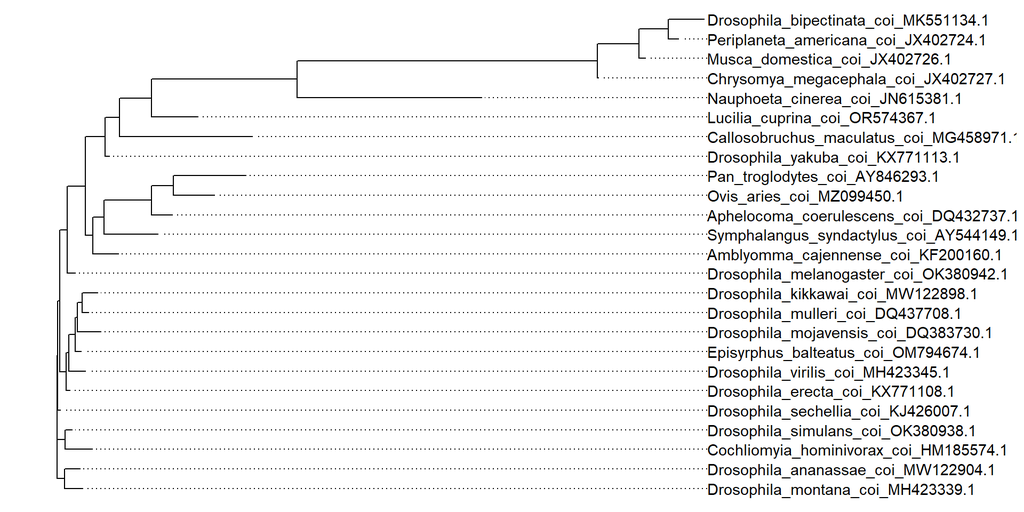

```r
gimme_fast <- readDNAStringSet("accession/coi_seq_format.fasta") # read in multi fasta as a string set
alignment <- AlignSeqs(gimme_fast) # perform profile-to-profile alignment
distance <- dist.dna(as.DNAbin(alignment)) # find pairwise distances
tree <- njs(distance) # have to use this because there is studd missing from the distance matrix
ape::write.tree(tree, file='tree/tree.txt') # write tree out in newick format
```

This tree shows weird groupings that I do not trust. I have a lot of drosophila data, but it is weird that it is popping up in random groups.

I still wanted to look at some data along side this tree for funsies. There were some outliers that made it very hard to see the details so I removed them in a second tree in order to plot data side by side.

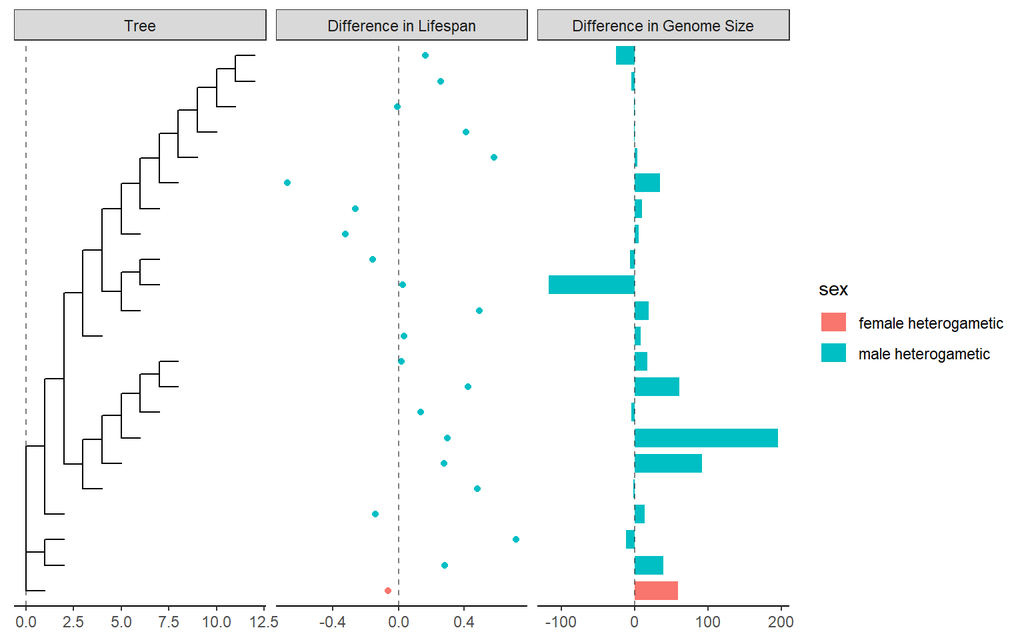

```r
tree2 <- drop.tip(tree, tip = 12) # removes pan troglodytes because we know that one is weird and wrong
tree2 <- drop.tip(tree2, tip = 11) # removes ovis aries because it is so big we can't see anything else
tree2 <- drop.tip(tree2, tip = 1)
ape::write.tree(tree2, file='tree/tree2.txt')
```

[figure not shown]

BEAST tree faceted with larger differences removed to take a look at the smaller data

While using MAFFT online, I saw that some of my sequences could have been reversed which could explain some of the weird relationships seen with the neighbor joined tree. Here is a quick tree made with bayesian methodology going through 1,000,000 and burnout at 250. The program used was beast.

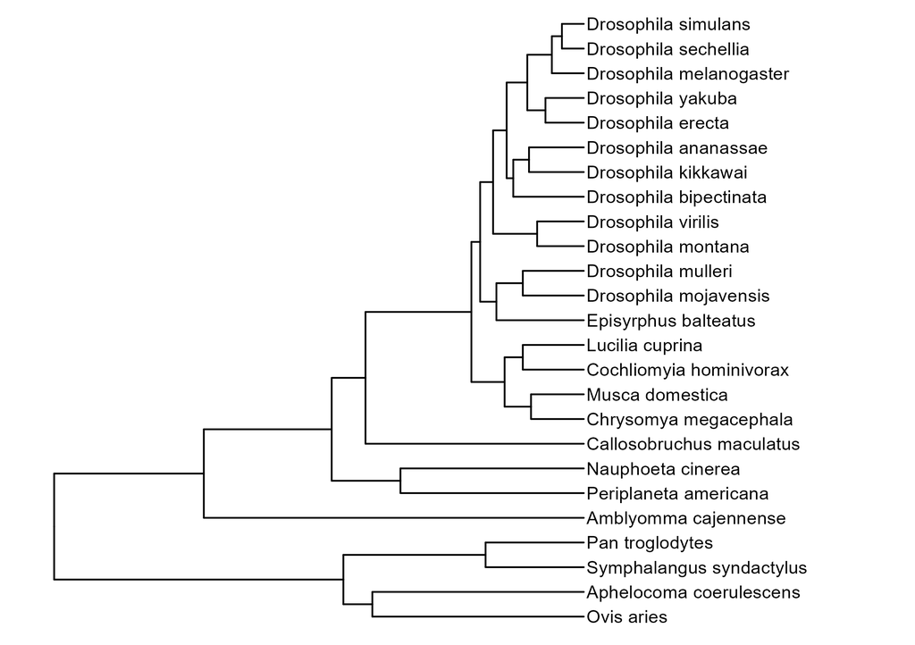

BEAST tree

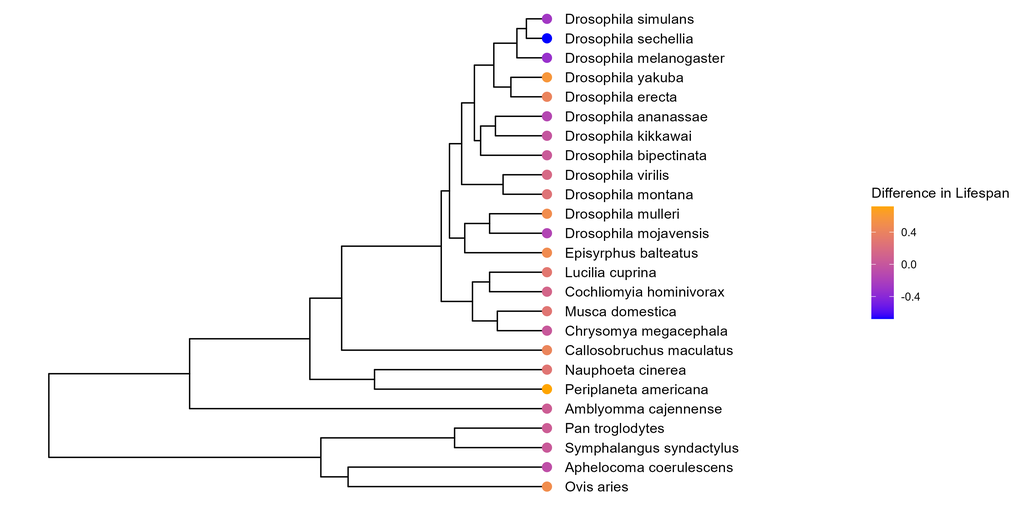

BEAST tree with natural log lifespan data plotted in gradient